# Exploratory Data Analysis of Salary Data: Understanding Relationships and Patterns in Employment Characteristics

```python
import pandas as pd
import numpy as np
import matplotlib.pyplot as plt
import seaborn as sns
```

## Import Data, Checking and Cleaning

```python
salaries_df = pd.read_csv('salaries.csv')
salaries_df.head()
```

|  | work_year | experience_level | employment_type | job_title | salary | salary_currency | salary_in_usd | employee_residence | remote_ratio | company_location | company_size |
| --- | --- | --- | --- | --- | --- | --- | --- | --- | --- | --- | --- |
| 0 | 2024 | MI | FT | Data Scientist | 120000 | USD | 120000 | AU | 0 | AU | S |
| 1 | 2024 | MI | FT | Data Scientist | 70000 | USD | 70000 | AU | 0 | AU | S |
| 2 | 2024 | MI | CT | Data Scientist | 130000 | USD | 130000 | US | 0 | US | M |
| 3 | 2024 | MI | CT | Data Scientist | 110000 | USD | 110000 | US | 0 | US | M |
| 4 | 2024 | MI | FT | Data Science Manager | 240000 | USD | 240000 | US | 0 | US | M |

```python
salaries_df.info()
```

```
<class 'pandas.core.frame.DataFrame'>
RangeIndex: 16494 entries, 0 to 16493
Data columns (total 11 columns):
 #   Column              Non-Null Count  Dtype
---  ------              --------------  -----
 0   work_year           16494 non-null  int64
 1   experience_level    16494 non-null  object
 2   employment_type     16494 non-null  object
 3   job_title           16494 non-null  object
 4   salary              16494 non-null  int64
 5   salary_currency     16494 non-null  object
 6   salary_in_usd       16494 non-null  int64
 7   employee_residence  16494 non-null  object
 8   remote_ratio        16494 non-null  int64
 9   company_location    16494 non-null  object
 10  company_size        16494 non-null  object
dtypes: int64(4), object(7)
memory usage: 1.4+ MB
```

```python
salaries_df.shape
```

```
(16494, 11)
```

```python
salaries_df[salaries_df.duplicated]
```

|  | work_year | experience_level | employment_type | job_title | salary | salary_currency | salary_in_usd | employee_residence | remote_ratio | company_location | company_size |
| --- | --- | --- | --- | --- | --- | --- | --- | --- | --- | --- | --- |
| 111 | 2024 | SE | FT | Research Analyst | 130000 | USD | 130000 | US | 0 | US | M |
| 207 | 2024 | SE | FT | Data Scientist | 146000 | USD | 146000 | US | 0 | US | M |
| 227 | 2024 | SE | FT | ML Engineer | 25000 | USD | 25000 | US | 0 | US | M |
| 228 | 2024 | SE | FT | Data Scientist | 155000 | USD | 155000 | US | 100 | US | M |
| 262 | 2024 | MI | FT | Data Scientist | 110000 | USD | 110000 | US | 100 | US | M |
| ... | ... | ... | ... | ... | ... | ... | ... | ... | ... | ... | ... |
| 16195 | 2022 | MI | FT | Data Scientist | 78000 | USD | 78000 | US | 100 | US | M |
| 16196 | 2022 | SE | FT | Data Engineer | 135000 | USD | 135000 | US | 100 | US | M |
| 16197 | 2022 | SE | FT | Data Engineer | 115000 | USD | 115000 | US | 100 | US | M |
| 16336 | 2021 | MI | FT | Data Engineer | 200000 | USD | 200000 | US | 100 | US | L |
| 16450 | 2021 | MI | FT | Data Scientist | 76760 | EUR | 90734 | DE | 50 | DE | L |

6401 rows × 11 columns

###### In this analysis, we are assuming that the data represents collected research data and may contain duplicate values. Instead of removing these duplicates, we will retain them and calculate average statistics based on the entire dataset. This approach allows us to consider all data points in our analysis, providing a comprehensive understanding of the average values across different variables.

```python
salaries_df.isnull().sum()
```

```
work_year             0
experience_level      0
employment_type       0
job_title             0
salary                0
salary_currency       0
salary_in_usd         0
employee_residence    0
remote_ratio          0
company_location      0
company_size          0
dtype: int64
```

```python
salaries_df.describe()
```

|  | work_year | salary | salary_in_usd | remote_ratio |
| --- | --- | --- | --- | --- |
| count | 16494.000000 | 1.649400e+04 | 16494.000000 | 16494.000000 |
| mean | 2023.224991 | 1.637878e+05 | 149713.575725 | 32.044986 |
| std | 0.713405 | 3.406017e+05 | 68516.136918 | 46.260201 |
| min | 2020.000000 | 1.400000e+04 | 15000.000000 | 0.000000 |
| 25% | 2023.000000 | 1.020000e+05 | 101517.500000 | 0.000000 |
| 50% | 2023.000000 | 1.422000e+05 | 141300.000000 | 0.000000 |
| 75% | 2024.000000 | 1.873422e+05 | 185900.000000 | 100.000000 |
| max | 2024.000000 | 3.040000e+07 | 800000.000000 | 100.000000 |

## Data Analysis

###### For the data transformation part, salary_in_usd is already in the same currency across all locations. Therefore, there's no need to convert the salary to a new currency format. In order to maintain consistency throughout the dataset, we will continue with the calculations using the USD format.

```python
salaries_df.work_year.value_counts()
```

```
work_year
2023    8519
2024    6027
2022    1655
2021     218
2020      75
Name: count, dtype: int64
```

```python
salaries_df.experience_level.value_counts()
```

```
experience_level
SE    10652
MI     4024
EN     1319
EX      499
Name: count, dtype: int64
```

```python
salaries_df.job_title.value_counts()
```

```
job_title
Data Engineer                    3456
Data Scientist                   3312
Data Analyst                     2428
Machine Learning Engineer        1703
Research Scientist                529
                                 ...
Quantitative Research Analyst       1
AWS Data Architect                  1
Analytics Engineering Manager       1
Marketing Data Scientist            1
Data Analytics Associate            1
Name: count, Length: 155, dtype: int64
```

```python
salaries_df.remote_ratio.value_counts()
```

```
remote_ratio
0      11084
100     5161
50       249
Name: count, dtype: int64
```

```python
salaries_df.company_location.value_counts()
```

```
company_location
US    14478
GB      694
CA      455
ES      133
DE      105
      ...
AM        1
QA        1
AD        1
EC        1
MD        1
Name: count, Length: 77, dtype: int64
```

```python
salaries_df.company_size.value_counts()
```

```
company_size
M    15268
L     1038
S      188
Name: count, dtype: int64
```

### Salary Analysis by Job Title : 5-Year Summary

```python
mean_salary_by_title = salaries_df.groupby('job_title')['salary_in_usd'].mean()
max_salary_by_title = salaries_df.groupby('job_title')['salary_in_usd'].max()
min_salary_by_title = salaries_df.groupby('job_title')['salary_in_usd'].min()
count_by_title = salaries_df.groupby('job_title').size()

df_by_title = pd.DataFrame(mean_salary_by_title).reset_index()
df_by_title.columns = ['Job Title', 'Mean Salary']

df_by_title['Max Salary'] = df_by_title['Job Title'].map(max_salary_by_title)
df_by_title['Min Salary'] = df_by_title['Job Title'].map(min_salary_by_title)
df_by_title['Count'] = df_by_title['Job Title'].map(count_by_title)

df_by_title = round(df_by_title.sort_values(by='Mean Salary', ascending=False),2)
df_by_title
```

|  | Job Title | Mean Salary | Max Salary | Min Salary | Count |
| --- | --- | --- | --- | --- | --- |
| 12 | Analytics Engineering Manager | 399880.00 | 399880 | 399880 | 1 |
| 89 | Data Science Tech Lead | 375000.00 | 375000 | 375000 | 1 |
| 110 | Head of Machine Learning | 299758.43 | 448000 | 76309 | 7 |
| 131 | Managing Director Data Science | 280000.00 | 300000 | 260000 | 2 |
| 9 | AWS Data Architect | 258000.00 | 258000 | 258000 | 1 |
| ... | ... | ... | ... | ... | ... |
| 144 | Quantitative Research Analyst | 51000.00 | 51000 | 51000 | 1 |
| 111 | Insight Analyst | 50090.64 | 75000 | 30760 | 14 |
| 41 | Compliance Data Analyst | 45000.00 | 60000 | 30000 | 2 |
| 37 | CRM Data Analyst | 40000.00 | 40000 | 40000 | 1 |
| 138 | Principal Data Architect | 38154.00 | 38154 | 38154 | 1 |

155 rows × 5 columns

###### Based on global statistics, the report presents a summary of average earnings for various job titles for 5 years (from 2020 to 2024). A few notable points include that positions like Head of Machine Learning, Data Science Tech Lead, and Analytics Engineering Manager have the highest average pay, demonstrating their strategic significance and demand. On the other hand, the typical salary for positions like CRM/Compliance Data Analyst and Principal Data Architect is lower.

### Salary Analysis by Experience Level: 5-Year Trend

```python
mean_salary_by_experience = round(salaries_df.groupby(["work_year", "experience_level"])["salary_in_usd"].mean(),2).reset_index()
pivot_table = mean_salary_by_experience.pivot(index="experience_level", columns="work_year", values="salary_in_usd")
pivot_table
```

| work_year experience_level | 2020 | 2021 | 2022 | 2023 | 2024 |
| --- | --- | --- | --- | --- | --- |
| EN | 69840.67 | 63463.07 | 80018.70 | 91166.31 | 98001.71 |
| EX | 179958.25 | 186128.00 | 188260.29 | 191314.19 | 202374.18 |
| MI | 91870.94 | 86818.39 | 102745.58 | 123821.31 | 134702.69 |
| SE | 138648.89 | 125989.75 | 147903.35 | 165421.03 | 166932.43 |

###### The analysis shows a steady upward trend in average pay for each experience level throughout the five-year period based on global data. However, there was a slight decrease in 2021 compared to the previous year. This trend suggests a general upward movement in salary levels across different experience levels, indicating potential growth and stability in the job market.

### Salary Analysis by Employment Type: 5-Year Trend

```python
mean_salary_by_EMPtype = round(salaries_df.groupby(["work_year", "employment_type"])["salary_in_usd"].mean(),2).reset_index()
pivot_table = mean_salary_by_EMPtype.pivot(index="employment_type", columns="work_year", values="salary_in_usd")
pivot_table
```

| work_year employment_type | 2020 | 2021 | 2022 | 2023 | 2024 |
| --- | --- | --- | --- | --- | --- |
| CT | 68251.00 | 263666.67 | 69545.25 | 105682.67 | 103013.00 |
| FL | 60000.00 | 41851.67 | 70130.75 | 39250.00 | 33007.00 |
| FT | 106759.81 | 99485.74 | 134882.54 | 153866.98 | 150945.98 |
| PT | 18817.50 | 43355.75 | 74578.83 | 69820.00 | 100631.09 |

### Mean Salary Distribution by Remote Ratio

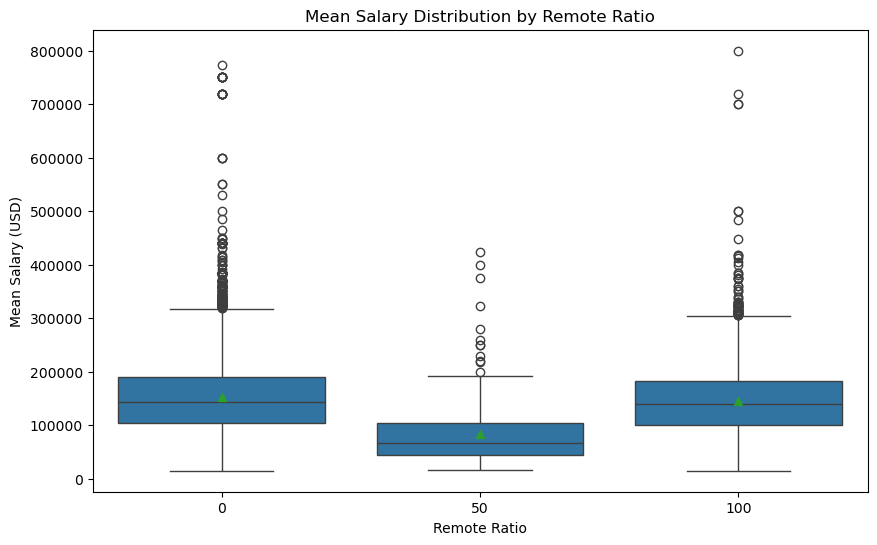

```python
mean_by_remote_ratio = salaries_df.groupby("remote_ratio")["salary_in_usd"].mean()

plt.figure(figsize=(10, 6))
sns.boxplot(x="remote_ratio", y="salary_in_usd", data=salaries_df, showmeans=True)

plt.title('Mean Salary Distribution by Remote Ratio')
plt.xlabel('Remote Ratio')
plt.ylabel('Mean Salary (USD)')

plt.show()
```

###### Although there may be outliers present, our analysis highlights a clear trend: mean salaries are highest in fully remote and non-remote work environments, with a notable decrease is observed in partially remote settings. This shows that policies regarding remote work and pay scales are correlated, highlighting the strategic significance of remote work arrangements in determining pay scales.

### Mean Salary Distribution by Company Size

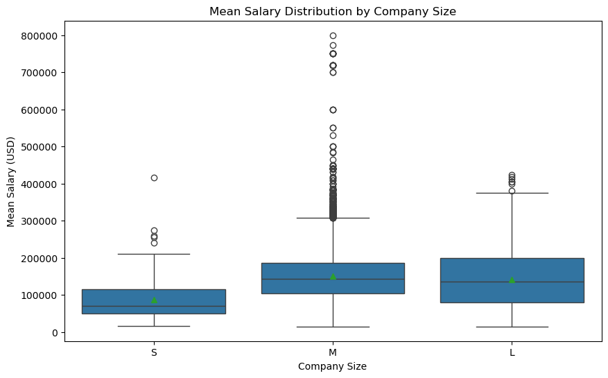

```python
mean_by_companysize = salaries_df.groupby("company_size")["salary_in_usd"].mean()

plt.figure(figsize=(10, 6))
sns.boxplot(x="company_size", y="salary_in_usd", data=salaries_df, showmeans=True)

plt.title('Mean Salary Distribution by Company Size')
plt.xlabel('Company Size')
plt.ylabel('Mean Salary (USD)')

plt.show()
```

###### The data shows a meticulous relationship between company size and salary levels even in the cases of outliers in median-sized businesses. Although median-sized companies may experience fluctuations in individual salary offerings, the overall trend indicates that averate salaries at median and large-sized companies tend to be higher.

### Mean Salary Distribution by Company Location

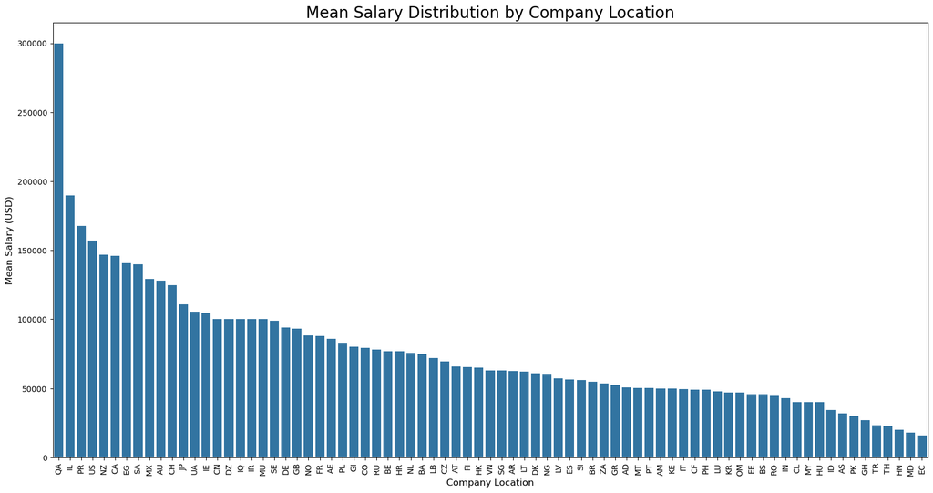

```python
mean_by_location = round(salaries_df.groupby("company_location")["salary_in_usd"].mean(), 2)
sorted_location = sorted(mean_by_location.items(), key=lambda kv: kv[1], reverse=True)
location_df = pd.DataFrame(sorted_location, columns=["company_location", "mean_salary"])

plt.figure(figsize=(20, 10))
sns.barplot(data=location_df, x="company_location", y="mean_salary",linewidth=2)
plt.xticks(rotation=90)
plt.xlabel("Company Location", size = 12)
plt.ylabel("Mean Salary (USD)", size =12)
plt.title("Mean Salary Distribution by Company Location", size = 20)
plt.show()
```

###### The difference in average salaries between different nations highlights the diversity of the world's salary markets and economic environments. Qatar has the highest average salary by far, whereas Israel, Puerto Rico, and the United States have greater average incomes, which may indicate strong economies and booming businesses. However, the average salary in nations like Ecuador, Moldova, and Honduras is lower, which may indicate different cost of living considerations or possible economic difficulties. The significance of comprehending regional economic dynamics and their influence on compensation levels is highlighted by this discrepancy.